# Electricity & Magnetism Tutorial Questions, Week 16

Author

Richard J. Stancliffe

## Question 1

A charge of +36μC is at a point A. At a point B located 8.0 m away, there is a second charge of −16μC. Calculate the electric field at each of the following points:

a.) a point located 6m away from A and 2m away from B,

b.) a point located 10m away from A and 2m away from B,

Remember that the electric field is a *vector* quantity – it must have both magnitude and direction.

## Question 2

Three charges are arranged in a line as shown in the figure below.

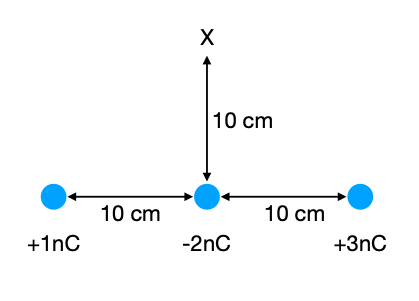

Calculate:

1. The total force acting on the charge in the middle (-2nC).
2. The electric potential energy U of the three charges
3. The electric potential at point X
4. The electric field at point X
5. The force that a charge of -2nC would experience if it was placed at point X.

## Question 3

On the surface of a sphere with a radius of 10 cm 10000 electrons are evenly spread out.

a.) Calculate the electric field at a point 50 cm away from the center of the sphere.

b.) Calculate the electric field at a point 5 cm away from the center of the sphere.

c.) This sphere is placed inside a hollow sphere with a radius of 20 cm. Uniformly spread out over the surface of this sphere are 20000 protons. Calculate the electric field at a point 50 cm away from the center of the sphere.

## Question 4

In a vacuum, a proton ($m_p = 1.673 \times 10^{−27}\,$kg) is travelling at $1 \times 10^6\,$m/s from very, very far away towards another proton that is fixed at its position. The electrostatic potential energy U between two point charges is given by:
$$U = \frac{1}{4\pi\epsilon_0}\frac{q_1q_2}{r}$$

Calculate how close the protons approach each other.

Hint: The question might look very difficult at first, but it is very similar to throwing a ball up in the air. You convert kinetic energy into potential energy. At the moment where the distance is the closest, all kinetic energy is converted into potential energy.

## Question 5

Two parallel plates are placed 5mm apart from one another to form a capacitor. A voltage of 20 V is applied across the plates creating an electric field as shown in the diagram below.

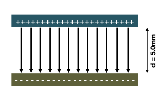

a.) Calculate the strength of the electric field inside the capacitor.

b.) What is the electric field *outside* the capacitor? You do not need to calculate this – just explain it!

c.) A proton is place in the centre of the two plates. It is then moved from left to right by 2cm. What is the difference in potential energy?

d.) The proton is now moved upward by 0.1 mm. Calculate the change in potential energy.

e.) The proton is now moved downward by 0.1 mm. What is the change in potential energy?